# Chi-Square Tests

Day 23

Claire Kelling

Carleton College  
STAT 120 - Fall 2026

## Question of the Day

Did you do anything fun this weekend? 😊

## Today’s Topics

Housekeeping:

- Friday’s GPA example was from Stinebrickner Ralph & Stinebrickner Todd R., 2008. “The Causal Effect of Studying on Academic Performance,” The B.E. Journal of Economic Analysis & Policy, De Gruyter, vol. 8(1), pages 1-55.
- EDA due Wednesday!

Topics covered today:

- Finishing up QQ plots
- Goodness-of-fit Hypotheses
- Chi-square Test for Association

# Comparing Counts

## Tests for Categorical Variable(s)

**Goodness-of-fit Test**

Test a claim about the distribution of one categorical variable

- E.g. are 6 M&M colors equally likely?
- E.g. is Tim Walz’s approval rating 40%?

**Chi-square Test for Association**

Determine if a relationship between two categorical variables is statistically discernible

- E.g. Does M&M color distribution depend on type  
  (chocolate vs. peanut)?

## Goodness-of-fit Hypotheses

**GOF Hypotheses**

$H_0$: gives specific proportion values for all levels

$H_a$: null is not true

- Alternative is always “two-sided”

**Example**

- Are all M&M colors equally likely?

$H_0: p_{red} = p_{orange} = p_{green} = p_{blue} = p_{yellow} = p_{black} = \frac{1}{6}$

$H_a:$ at least one is not $\frac{1}{6}$

## Chi-square Test for Association Hypotheses

**Chi-square Hypotheses**

Hypotheses look like:

- $H_0$: two categorical variables **are** **not** associated
- $H_a$: two categorical variables **are** associated

Alternative is always “two-sided”

**Example**

Does M&M color distribution depend on type (chocolate vs. peanut)?

- $H_0$ : there is no association between M&M color and type
- $H_a$ : there is an association between M&M color and type

## Chi-Square Test Statistic

We **can’t** use the familiar test statistic form:
$$\frac{\text{stat} - \text{null}}{\text{SE}}$$

- We have more than two stats (counts per category, proportions)
- More than one null value

Chi-Square Test Statistic:

$$\chi^2 = \sum_{all counts} \frac{(\text{expected count} - \text{observed count})^2}{\text{expected count}}$$

- Expected counts are computed by **assuming $H_0$ is true**

## Expected Counts

**GOF**: for each level,

expected count = $n\text{ }\times$ null proportion

**Association:** for each combination in a **two-way table**

expected count = $\frac{\text{row total } \times \text{ column total}}{n}$

## P-value calculation

$$\chi^2 = \sum_{all counts} \frac{(\text{expected count} - \text{observed count})^2}{\text{expected count}}$$

- For both types of test, large chi-square test stat values support the alternative hypothesis so

  $$\text{p-value} = P(\chi^2 \geq \text{observed } \chi^2)$$
- Always a **right-tailed** p-value
- Based on a $\chi^2$ distribution with appropriate $df$, instead of Normal or $t$ distribution

## Chi-Square Distribution

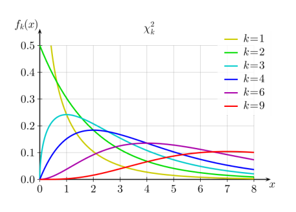

## Null model for Test Statistic

**Options for computing the p-value:**

**Randomization/Permutation**

- Simulate new data consistent with $H_0$ and recompute the $\chi^2$ test stat
- **GOF:** generate samples consistent with $H_0$ proportions
- **Association:** permute the values of one variable column to break the link that could exist in the data between both variables

**Chi-square distribution (probability model)**

- Chi-square distribution also has **degrees of freedom**
- **GOF**: Use # of levels - 1 degrees of freedom
- **Association**: Use $(r-1)(c-1)$ degrees of freedom, where $r$ = number of rows and $c =$ number of columns

## Chi-Square Perm Dist Example

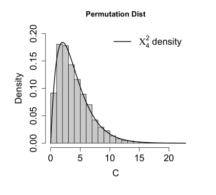

- **Example:** Categorical variable with five levels (4 degrees of freedom for GOF test)
- Create a permutation distribution based on $H_0$ and compare to what we observed
- OR calculate the p-value based on probability model of $\chi^2$ dist

## Other Topics

**Condition to Check**

- Generally, no cell should be “too small” for expected counts
- **Rule of thumb:** $\chi^2$ approximation is good if each expected count is $\geq$ 5

**R function**

```r
chisq.test(counts_tab, p=c(.4,.4,.2)) #example of GOF
chisq.test(counts_tab) #example of Assoc Test, just need table of counts
```

**What if you find a difference?**

- If p-value is small, you can describe association:
  - Plot the data- find which values seem to be the most different (for example, stacked bar chart)
  - You can give a CI for an interesting **pairwise** comparison
  - Beware of multiple comparisons problem

# Handout

## Reminder of Hypotheses

**GOF Hypotheses**

$H_0$: gives specific proportion values for all levels

$H_a$: null is not true

- Alternative is always “two-sided”

**Chi-square Hypotheses**

Hypotheses look like:

- $H_0$: two categorical variables **are not** associated
- $H_a$: two categorical variables **are** associated

Alternative is always “two-sided”

## Chi-Square Test Statistic

We can’t use the familiar test statistic form:
$$\frac{\text{stat} - \text{null}}{\text{SE}}$$

- We have more than two stats (counts, proportions)
- More than one null value

Chi-Square Test Statistic:

$$\chi^2 = \sum_{all counts} \frac{(\text{expected count} - \text{observed count})^2}{\text{expected count}}$$

- Expected counts are computed by **assuming $H_0$ is true**

## Handout Examples:

Going to focus on two questions from a previous survey of STAT 120 Students:

- Which statement below best describes your religious beliefs and practices?
  - religious and actively practicing my religion
  - religious but not actively practicing
  - not religious
- How comfortable do you feel expressing your political views at Carleton?
  - rarely, if ever, comfortable
  - sometimes comfortable
  - almost always comfortable

## Handout

Work through Problem 1 on the handout! We will recap after problem 1.

One RStudio open per group!

# GOF Example

## 1a) GOF Example

**Class survey**: Is the distribution of religion in the population of Stat 120 students: 60% not religious, 20% active religious and 20% not active religious?

- Assume that responses represent a random sample from all STAT 120 students from a previous term
- $H_0$: $p_{not.rel} = 0.6$, $p_{rel.act} = 0.2$, $p_{rel.not.act} = 0.2$
- $H_a$: at least one proportion above is wrong

## 1b) GOF Example

- Read in data, omit rows with NA for Question.8 (on religion)

```r
survey <- read.csv("https://www.math.carleton.edu/ckelling/intro_data/Survey.csv",
    stringsAsFactors = TRUE)
survey <- tidyr::drop_na(survey, Question.8)
```

- Observed counts (note the long category names)

```r
table(survey$Question.8)
##
## not religious
## 219
## religious and actively practicing my religion
## 65
## religious but not actively practicing
## 119
```

## 1b) GOF Example

- Rename levels

```r
library(forcats)
survey$Question.8 <- fct_recode(survey$Question.8,  #<<
    "religious, active" = "religious and actively practicing my religion",
    "religious, not active" = "religious but not actively practicing")
```

- Check Work

```r
table(survey$Question.8)
##
## not religious      religious, active      religious, not active
##           219                    65                       119
```

## 1b) GOF Example

- Reorder from least to most religious:

```r
survey$Question.8 <- fct_relevel(survey$Question.8,
    "not religious",
    "religious, not active",
    "religious, active")
```

- Check work:

```r
table(survey$Question.8)
##
## not religious      religious, not active     religious, active
##           219                       119                    65
```

## 1b) GOF Example

- Store counts in new data frame

```r
counts <- table(survey$Question.8)
counts
##
## not religious     religious, not active     religious, active
##           219                      119                   65
sum(counts) # sample size (responses)
## [1] 403
```

- The number of respondents to this question (sample size) is 403.

## 1b) GOF Example

- Proportions per category

```r
proportions(counts)
##
## not religious     religious, not active     religious, active
##     0.5434243               0.2952854           0.1612903
```

## 1b) GOF Example

- Create a visualization

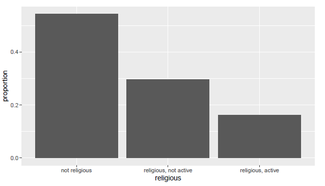

```r
ggplot(survey, aes(x = Question.8)) +
  geom_bar(aes(y = ..prop.., group = 1)) +  #<<
  labs(y = "proportion", x = "religious")
```

## 1c) GOF Example: Hypotheses

- Expected counts assuming $H_0$ is true?

  $H_0: p_{not.rel} = 0.6$, $p_{rel.act} = 0.2$, $p_{rel.not.act} = 0.2$
- **Expected Counts:**
  - Not religious: $403 \times 0.6$ = 241.8
  - Not active, religious: $403 \times 0.2 = 80.6$
  - Active religious: $403 \times 0.2 = 80.6$

## 1d) GOF Example

- Compute the chi-square test statistic:

  $$\chi^2 = \sum_{all counts} \frac{(\text{expected count} - \text{observed count})^2}{\text{expected count}}$$

  $$\chi^2 = \frac{(219-241.8)^2}{241.8} + \frac{(119-80.6)^2}{80.6} + \frac{(65-80.6)^2}{80.6} \approx 23.464$$

## 1e) GOF Example

- **P-value:** all expected counts are well above 5, so we can use the chi-square probability model
- Degrees of freedom are $3-1 = 2$ since there are 3 levels (answers) to the religion variable
- How would I use pchisq()?

```r
1-pchisq(23.464, 2)
#8.032618e-06
```

- The p-value is about 0.

## 1e) GOF Example

- P-value is $P(\chi^2_{2df} \geq 23.464)$

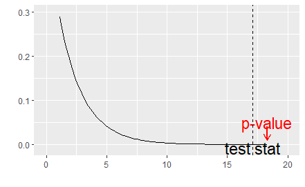

## 1f) GOF Example

- Conclusion?
- We have evidence that supports the alternative, so we can reject the possibility that the rate of religiousness is as stated in the null ($\chi^2 = 23.464, df = 2, p \approx 0$).

## g) GOF Example

- We can also do GOF with **chisq.test** command

```r
religion.gof <- chisq.test(counts, p=c(.6,.2,.2))
religion.gof
##
## Chi-squared test for given probabilities
##
## data: counts
## X-squared = 23.464, df = 2, p-value = 8.033e-06

religion.gof$expected
## not religious    religious, not active    religious, active
##         241.8                  80.6              80.6
```

- The suggested guidelines are expected counts of at least 5 so we can trust the p-value calculated from the chi-square distribution.

# Association Example

## 2a) Association Example

Does political comfort level depend on religion?

- $H_0:$

  There is no association between religion and comfort level
  - **Implies**: the distribution of comfort level is the same for all three religion types
- $H_a$:

  There is an association between religion and comfort level
  - **Implies**: the distribution of comfort level is the different for at least one religion type.

## 2b) Association Example

Data clean up:

- Remove NA for Question.9 (political comfort)
- Rename the response categories
- Reorder the response categories

```r
table(survey$Question.9)
##
##   almost always comfortable     rarely, if ever, comfortable
##                         184                                 57
##       sometimes comfortable
##                         161
```

## 2b) Association Example

Rename comfort level something more manageable

```r
survey$Question.9 <- fct_recode(survey$Question.9,
    "almost always" = "almost always comfortable",
    "rarely" = "rarely, if ever, comfortable",
    "sometimes" = "sometimes comfortable")
```

Reorder comfort level

```r
survey$Question.9 <- fct_relevel(survey$Question.9,
                      "almost always", "sometimes", "rarely")
table(survey$Question.9)  # always check work!
#almost always     sometimes        rarely
#          184             161            57
```

## 2b) Association Example

- Observed distribution of comfort level given religiousness

```r
counts <- table(survey$Question.8, survey$Question.9)
counts
##
##                       almost always sometimes rarely
## not religious                   118        86     15
## religious, not active           45        50     23
## religious, active                21        25     19

sum(counts) # number of respondents
## [1] 402
```

## 2b) Association Example

Get two-way table

```r
proportions(counts,1)
##
##                        almost always     sometimes         rarely
## not religious           0.53881279       0.39269406    0.06849315
## religious, not active   0.38135593       0.42372881    0.19491525
## religious, active       0.32307692       0.38461538    0.29230769
```

- There is a much higher rate of “almost always comfortable” for the **not** religious respondents (53.9%) than those that are religious (not active: 38.1%; active: 32.3%).

## 2b) Association Example

Create plot of two categorical variables:

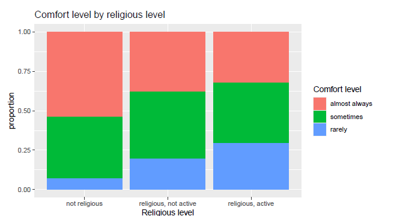

```r
ggplot(survey, aes(x=Question.8, fill=Question.9)) +
  geom_bar(position="fill") +
  labs(fill = "Comfort level", x = "Religious level", y = "proportion", title="Comfort level by religious level")
```

## 2c) Association Example

- Expected counts assuming no association (null)?
  - Expected number of respondents who are “not religious” and “almost always comfortable”?
  - Is **not** 1/9 of all respondents!
- There are 219 “not religious” respondents (row total)
- The overall rate (ignoring religion) of “almost always comfortable” is $\frac{184}{402}$, or about 45.8%.

## 2c) Association Example

- If religion isn’t related to comfort level, the expected number is about

  expected counts $= \frac{\text{row total} \times \text{column total}}{n} =$ $219 \times \frac{184}{402} = 100.239$
- Similar process for other categories

## 2d) Association Example

- Chi-square contribution for “not religious” and “almost always comfortable” cell?
- The contribution to the chi-square test stat from this category is 3.147.

  $$\frac{(118- 100.239)^2}{100.239} = 3.147$$

## 2e) Association Example

- Use chisq.test to finish the test stat calculation (who wants to add 9 cell contributions!)

```r
ComfortReligion <- chisq.test(survey$Question.8, survey$Question.9)
ComfortReligion

##
## Pearson's Chi-squared test
##
## data: survey$Question.8 and survey$Question.9
## X-squared = 28.49, df = 4, p-value = 9.922e-06
```

- The test stat value is 28.49.
- There are 3 categories for each variable, so the degrees of freedom will be $df = (3-1)(3-1) = 4$.

## 2g,h) Association Example

- Are the expected counts above 5?

```r
ComfortReligion$expected
##                        survey$Question.9
## survey$Question.8     almost always    sometimes    rarely
## not religious              100.23881     87.70896    31.052239
## religious, not active     54.00995      47.25871    16.731343
## religious, active          29.75124      26.03234    9.216418
```

## 2g,h) Association Example

- If we get a red warning when running chisq.test, it usually means the sample size conditions aren’t met to use the chi-square model. Instead run a randomization test with simulate.p.value = TRUE

```r
chisq.test(survey$Question.8, survey$Question.9, simulate.p.value = TRUE)
##
## Pearson's Chi-squared test with simulated p-value (based on 2000     replicates)
##
## data: survey$Question.8 and survey$Question.9
## X-squared = 28.49, df = NA, p-value = 0.0004998
```

## 2i) Association Example

- Describe the association!
- Which groups have the most different comfort levels?

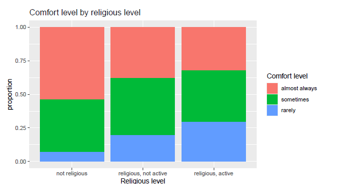

## 2i) Association Example

- 95% CI for the difference in the true proportions of “rarely comfortable” people in the not religious and actively religious groups.

  $p$ = proportion rarely comfortable
- 95% CI for $p_{not.relig} - p_{active}$

Back to EDA:

```r
table(survey$Question.8)
##
## not religious      religious, active      religious, not active
##           219                    65                       119
```

$n_{not.relig} = 219$, $n_{active} = 65$

## 2i) Association Examples

Explore proportions for each level (want proportion rarely comfortable for each religion type)

```r
proportions(counts,1)
##
##                        almost always     sometimes         rarely
## not religious           0.53881279       0.39269406    0.06849315
## religious, not active   0.38135593       0.42372881    0.19491525
## religious, active       0.32307692       0.38461538    0.29230769
```

```r
counts
##                       almost always sometimes rarely
## not religious                   118        86     15
## religious, not active           45        50     23
## religious, active                21        25     19
```

$\hat{p}_{not.rel} = \frac{15}{219} = 0.0684, \hat{p}_{active} = \frac{19}{65} = 0.2923$

## 2i) Association Example

- 95% CI for $p_{not.relig} - p_{active}$

$$0.06849 - 0.29231 \pm 1.96 \sqrt{\frac{0.06849(1-0.06849)}{219}+ \frac{0.29231(1-0.29231)}{65}}$$

$$-0.2238145 \pm 1.96 (0.0589394))$$

$$(-0.3393358, -0.1082933)$$

- I am 95% confident that the percentage of all non-religious STAT 120 students who are rarely comfortable is between 10.8 to 33.9 percentage points lower than the actively religious students.

## Next Class

Two$+$ means with ANOVA